# Miscellaneous Topics in Survey Sampling

PUBHBIO 7225 Lecture 23

Generative AI acknowledgment: Google Gemini was used to assist in generating alt text for images

## Outline

**Topics**

- Data Suppression
- Combining Survey Waves

**Activities**

- 23.1 Combining NSCH Waves (Years)

**Assignments**

- Quiz 5 (last one!) due Thursday 11/20/2025 11:59pm via Carmen

**Additional Remaining Due Dates**

- Group Project **slides** due Tuesday 12/2 (week after Thanksgiving)
- Individual Project due Tuesday 12/9 (last week of classes)
- Group Project **paper** due Thursday 12/18 (last day of finals)

## Data Suppression

- Surveys (based on probability samples) often have large sample sizes (relative to other study designs)
- However, some point estimates may still be quite variable (imprecise/large variance)
  - For example, for a subpopulation that is small and was not purposely oversampled
- Additionally, some estimates based on small numbers of people, or estimates for population groups that are small, might be **dangerous in terms of privacy**

> **Suppression** = Purposefully withholding / not releasing a specific estimate (to the public)
- Different statistical agencies use different rules about when to *suppress* results
  - Possible Reason 1: limit risk of disclosure – i.e., that you could figure out who answered the survey
  - Possible Reason 2: estimate is deemed “too variable” or “too unreliable”

## Example – Published Analysis using BRFSS

*Article: Racial and Ethnic Diﬀerences in Subjective Cognitive Decline — U.S., 2015–2020.*<sup>1</sup> ([link](http://dx.doi.org/10.15585/mmwr.mm7210a1))

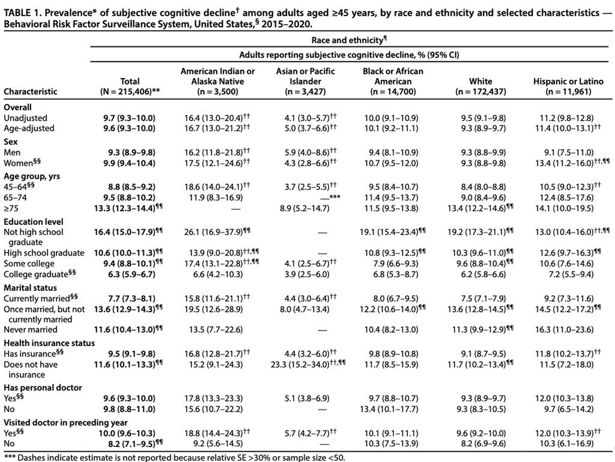

[^1]: MMWR Morb Mortal Wkly Rep 2023;72:249–255.

## Data Suppression Rules: Examples

- **Population Thresholds**
  - Only release estimates for areas/population groups that exceed a certain size
    - Example: *Areas or groups of 65,000 or more are eligible for estimates to be released*  
      (American Community Survey, ACS)
- **Restrictions on Numerators and/or Denominators of Proportions**
  - Based on the **unweighted** sample, suppress estimates with too few cases in the numerator or denominator of a proportion
    - Example: *Suppress estimates based on proportions with numerator <10*  
      (National Crime Victimization Survey, NCVS)
    - Example: *Suppress estimates based on proportions with denominator <30*  
      (National Survey of Family Growth, NSFG)

## Data Suppression Rules: Examples (con’t)

- **Relative Standard Error (RSE)** = SE of estimate, divided by estimate, times 100
  - $\displaystyle{RSE = 100 \times \frac{\widehat{SE}(\bar{y})}{|\bar{y}|}}$
  - Usually a cutoff (threshold) is chosen and estimates with **RSE above the threshold are suppressed**
    - Example: *Suppress estimates with RSE >30%*  
      (National Health Interview Survey, NHIS)
    - Example: *BRFSS results in the MMWR Table: Suppress estimates with RSE > 30%*
  - Sometimes RSE is modified for proportions:
    $$\frac{\widehat{SE}(\hat{p})/\hat{p}}{-\mathrm{ln}(\hat{p})}>.175$$
    when $\hat{p} \le$ 0.5

## RSE: Why Modify for p < 0.5?

A visualization of RSE (for an SRS) as a function of p is helpful:

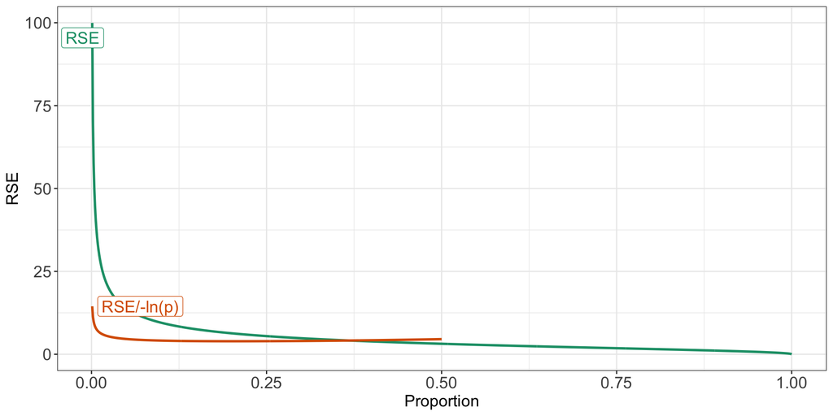

(n is set to 1,000 for the purposes of this visualization)

## Combining Survey Waves

- Many surveys are repeated (e.g., yearly, every 2 years) to monitor trends
- Combining **across survey waves** can also be used to estimate characteristics from small subpopulations
- Generally speaking, these are two different possible goals of combining survey waves:
1. Estimate a *change* in a mean/proportion and test the significance of the change
   - Example: Has the proportion of children aged 3-17 diagnosed with anxiety changed from 2017 to 2020? What is the estimate of the change?
2. Estimate a mean/proportion using data from multiple years *assuming that the mean/proportion has not changed over time*
   - Example: What is the (average) proportion of children aged 3-17 with an Autism Spectrum Disorder in the years 2017-2020?
- Assuming that **a new (cross-sectional) sample is taken each wave** (i.e., not a panel/longitudinal survey), samples from wave to wave are **independent**
- Thus combining across waves is straightfoward (it is what was done to produce the BFRSS table)

## Estimating Changes

- As long as the samples each year/wave are drawn independently:

| Year | True Population Value | Estimate | Variance of Estimate |
| --- | --- | --- | --- |
| 1 | $\theta_1$ | $\hat{\theta}_1$ | $V(\hat{\theta}_1)$ |
| 2 | $\theta_2$ | $\hat{\theta}_2$ | $V(\hat{\theta}_2)$ |
| Change | $\Delta = \theta_2-\theta_1$ | $\hat{\Delta}=\hat{\theta}_2-\hat{\theta}_1$ | $V(\hat{\Delta}) = V(\hat{\theta}_1) + V(\hat{\theta}_2)$ |

- Since $\hat{\theta}_1$ and $\hat{\theta}_2$ are **independent**, there is no covariance term!
- Calculate estimates in each year/wave, subtract to estimate the change, add the (estimated) variances to obtain the variance of the change, and test for change…

…or you can **pool the data from the waves** and let software do the analysis for you!

- Benefit to using software: can conduct more sophisticated analyses (e.g., test for linear change trend, adjust for covariates, etc.)

## Combining Waves of the Same Survey

- Two things to be careful about when pooling survey years:
1. Is the design the same in each year? E.g., strata, clustering, etc.
   - For many large surveys the answer will be yes – precisely because they want to facilitate trend analyses
   - If differences in strata definitions, may have to redefine to align correctly (e.g., “stratum 1”, “stratum 2” for all waves)
2. The sample weights – rescale or not rescaled?
   - Estimating changes in means/proportions – does not matter whether you rescale weights or not, estimates identical
   - Pooled estimates (e.g., prevalence in 2017-2020) – rescale weights so sum is the average population size by dividing by number of waves being combined
     - Technically, prevalence estimates will be identical with/without rescaling – but population counts will only be correct if you rescale

## Activity 23.1

Combining NSCH Waves (Years)